# Seeking for the phase-transition

František Kalvas

Department of Sociology, University of West Bohemia in Pilsen

2022-03-23

## Introduction

Main focus of this side project is to find phase-transition which happen when we are changing boundary/`acceptability of different opinion`. Result should be a simple graph showing how ESBG polarization changes with change of `acceptability of different opinion`.

## Loading data

Data are at http://github.com/frantisek901/Spirals/Experiment. Experiment is still running and I, FranČesko, from time to time actualize the `*.csv` files at GitHub, then I run script `experiment.R` which loads the data. But now, 2022-03-21, at least 60% of simulations are done (we are running 6 experiments, 3 are completely done, 3 are at 60% or more). Who is not interested in working with megabytes of `*.csv files`, might use compiled `phase.RData`.

Now we load and aggregate these data and factorize and rename selected variables:

```r
## Loading stored data
load("phase.RData")

df = phase %>%
  ## Selecting variables:
  select(opinions, boundary, `use_identity?`, id_threshold, ESBG) %>%

  ## Changing some variables to factors:
  mutate(id_threshold = if_else(`use_identity?`, id_threshold, NA_real_) %>% factor(exclude = ""),
         identity = if_else(`use_identity?`, "Identity used", "Identity not used") %>% factor(),
         opinions = factor(opinions)) %>%
  relocate(identity, .after = `use_identity?`) %>% select(-`use_identity?`) %>%

  ## Summarising:
  group_by(opinions, boundary,
           identity,
           id_threshold) %>%
  summarise(ESBG = mean(ESBG)) %>% ungroup() %>%

  ## Renaming variables according 2022-03-18 meeting:
  prejmenuj(1:4, c("Opinion dimensions:", "Acceptability of different opinion:", "Identity:",
                    "Narrowness of identity group:"))
```

## Graph

Now, let’s show our results graphically!

### Smooth curves

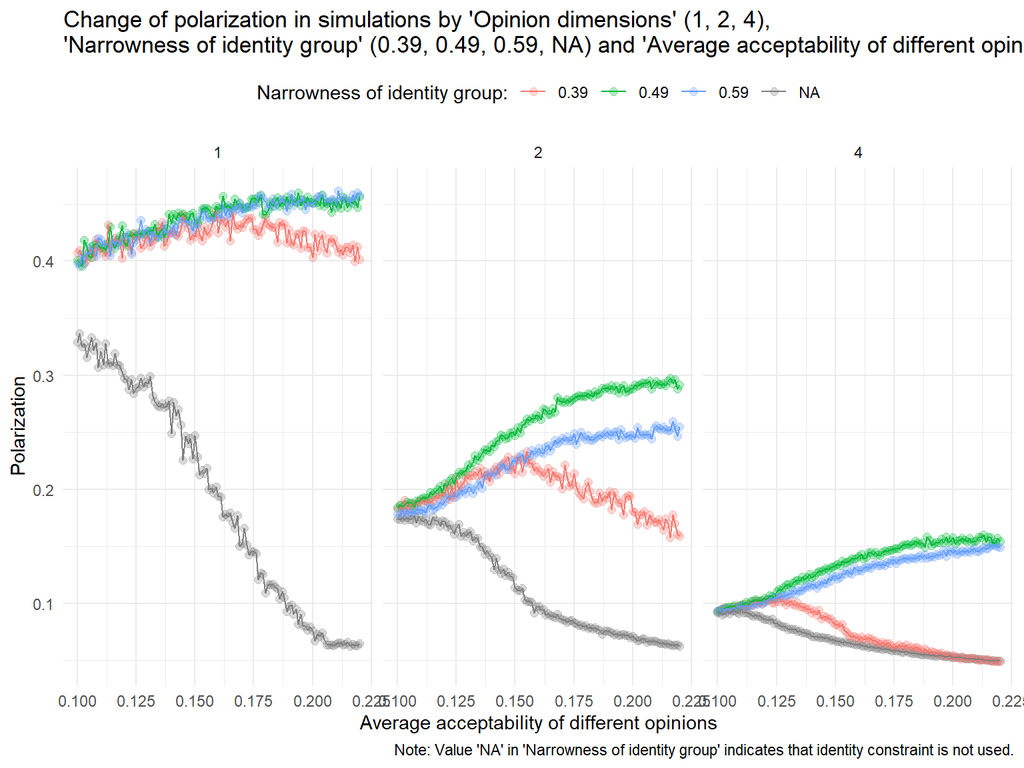

```r
df %>%
  ggplot(aes(x = `Acceptability of different opinion:`, y = ESBG,
             col = `Narrowness of identity group:`, group = `Narrowness of identity group:`)) +
  facet_wrap(vars(`Opinion dimensions:`), ncol=3) +
  geom_point(alpha = 0.3, size = 2) + geom_line() +
  labs(title = "Change of polarization in simulations by 'Opinion dimensions' (1, 2, 4),\n'Narrowness of identity group' (0.39, 0.49, 0.59, NA) and 'Average acceptability of different opinions' (0.1--0.22)",
       x = "Average acceptability of different opinions", y = "Polarization",
       caption = "Note: Value 'NA' in 'Narrowness of identity group' indicates that identity constraint is not used.") +
  guides(alpha = "none") +
  theme_minimal() +
  theme(legend.position = "top")
```

#### Note:

Both graphs contain same information, I’m just trying two different ways how to express it.

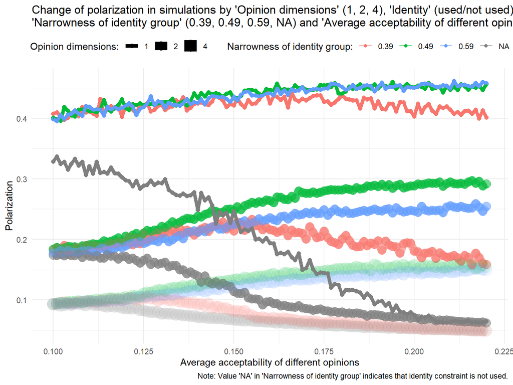

```r
df %>% mutate(grouppings = paste(`Narrowness of identity group:`, `Opinion dimensions:`, sep = "_")) %>%
  ggplot(aes(x = `Acceptability of different opinion:`, y = ESBG,
             size = `Opinion dimensions:`, alpha = fct_rev(`Opinion dimensions:`),
             col = `Narrowness of identity group:`, group = grouppings)) +
  geom_point() + geom_line() +
  labs(title = "Change of polarization in simulations by 'Opinion dimensions' (1, 2, 4), 'Identity' (used/not used), \n'Narrowness of identity group' (0.39, 0.49, 0.59, NA) and 'Average acceptability of different opinions' (0.1--0.22)",
       x = "Average acceptability of different opinions", y = "Polarization",
       caption = "Note: Value 'NA' in 'Narrowness of identity group' indicates that identity constraint is not used.") +
  guides(alpha = "none") +
  theme_minimal() +
  theme(legend.position = "top")
```

For scenarios `using identity` we see that value of `Narrowness of identity group` 0.49 and 0.59 produce very similar results, but value 0.39 differs from them significantly in qualitative and quantitative respect. For higher values of value of `Narrowness of identity group` the polarization increases with the increase of `Average acceptability of different opinions`. Wait a minute and enjoy how paradoxical this result is! If the identity group is narrow, if I need people being really close in their opinion to recognize them as my in-group, then the more open (on the average) the public the more polarized the same public! Paradoxically, openness towards other opinions produces higher polarization! But now look at the smaller value of `Narrowness of identity group` (0.39) – for this value polarization `DECREASES` with the with the increase of `Average acceptability of different opinions`. WOW! BTW, here is another phase transition! Somewhere between 0.39 and 0.49 the pattern changes and it changes its slope, it exchanges the increase for the decrease. We might also say, that the increase of `Average acceptability of different opinions` opens the polarization scissors between higher and lower values of `Narrowness of identity group`. These scissors are the least open in 1D opinion space, the most in 2D, and in 4D space are little less open than in 2D, mainly because now the difference between 0.39 and 0.49 values are little less big.

We might see also inconspicuous pattern which motivates next graph – the less number of dimensions and the less `Narrowness of identity group` the less smooth or the more scattered the average trend line is. For scenarios `not using identity` we see very smooth curve in 4D, but also very scattered one in 1D space. In 1D space it is also evident that scenarios `using identity` respective their trend line is more scattered for value 0.39 of `Narrowness of identity group` than for values 0.49 and 0.59.

### Pulped clouds

For the first graph on pulped clouds we aggregate `Acceptability of different opinion` into 13 categories (we just round 121 original values to 2 digits). Two different levels of polarization are seeable here, but it doesn’t look like clouds…

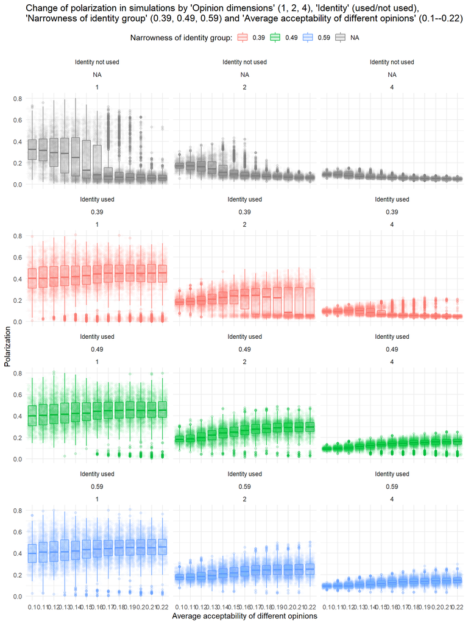

```r
## For presenting variability we try now boxplots on individual data (non-aggregated):
phase %>%
  # sample_n(20000) %>%
    ## Selecting variables:
  select(opinions, boundary, `use_identity?`, id_threshold, ESBG) %>%

  ## Changing some variables to factors:
  mutate(id_threshold = if_else(`use_identity?`, id_threshold, NA_real_) %>% factor(exclude = ""),
         opinions = factor(opinions),
         boundary = factor(round(boundary, digits = 2)),
         identity = if_else(`use_identity?`, "Identity used", "Identity not used") %>% factor()) %>%
  relocate(identity, .after = `use_identity?`) %>% select(-`use_identity?`) %>%

  ## Renaming variables according 2022-03-18 meeting:
  prejmenuj(1:4, c("Opinion dimensions:", "Acceptability of different opinion:", "Identity:",
                    "Narrowness of identity group:")) %>%

  ## Graph itself:
  ggplot(aes(x = `Acceptability of different opinion:`, y = ESBG,
             fill = `Narrowness of identity group:`,
             col = `Narrowness of identity group:`,
             group = `Acceptability of different opinion:`)) +
  facet_wrap(vars(`Identity:`, `Narrowness of identity group:`, `Opinion dimensions:`), ncol=3) +
  geom_boxplot(alpha = 0.2) +
  geom_jitter(alpha = 0.02) +
  labs(title = "Change of polarization in simulations by 'Opinion dimensions' (1, 2, 4), 'Identity' (used/not used), \n'Narrowness of identity group' (0.39, 0.49, 0.59) and 'Average acceptability of different opinions' (0.1--0.22)",
       x = "Average acceptability of different opinions", y = "Polarization") +
  theme_minimal() +
  theme(legend.position = "top")
```

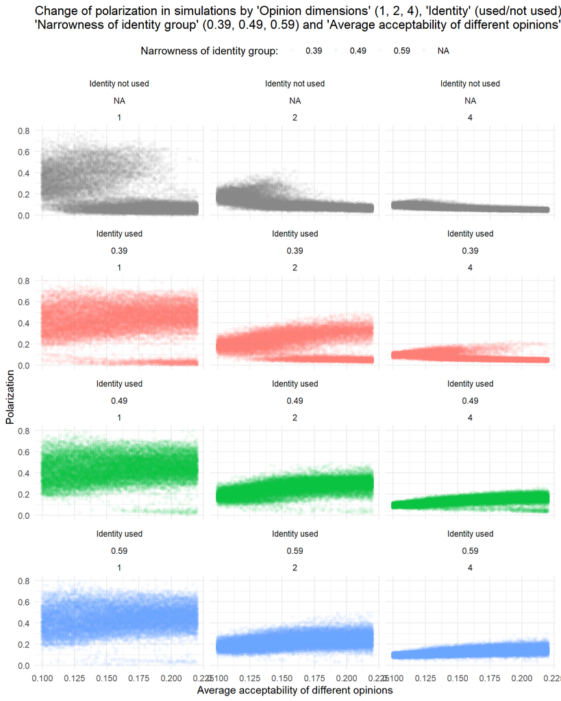

```r
## For presenting variability we try now boxplots on individual data (non-aggregated):
phase %>%
  # sample_n(20000) %>%
    ## Selecting variables:
  select(opinions, boundary, `use_identity?`, id_threshold, ESBG) %>%

  ## Changing some variables to factors:
  mutate(id_threshold = if_else(`use_identity?`, id_threshold, NA_real_) %>% factor(exclude = ""),
         opinions = factor(opinions),
         id_threshold = factor(id_threshold),
         identity = if_else(`use_identity?`, "Identity used", "Identity not used") %>% factor()) %>%
  relocate(identity, .after = `use_identity?`) %>% select(-`use_identity?`) %>%

  ## Renaming variables according 2022-03-18 meeting:
  prejmenuj(1:4, c("Opinion dimensions:", "Acceptability of different opinion:", "Identity:",
                    "Narrowness of identity group:")) %>%

  ## Graph itself:
  ggplot(aes(x = `Acceptability of different opinion:`, y = ESBG,
             fill = `Narrowness of identity group:`,
             col = `Narrowness of identity group:`,
             group = `Acceptability of different opinion:`)) +
  facet_wrap(vars(`Identity:`, `Narrowness of identity group:`, `Opinion dimensions:`), ncol=3) +
  geom_point(alpha = 0.05) +
  labs(title = "Change of polarization in simulations by 'Opinion dimensions' (1, 2, 4), 'Identity' (used/not used), \n'Narrowness of identity group' (0.39, 0.49, 0.59) and 'Average acceptability of different opinions' (0.1--0.22)",
       x = "Average acceptability of different opinions", y = "Polarization") +
  theme_minimal() +
  theme(legend.position = "top")
```

WOOOOOOOOOOOOOOOOOOOOOOOHOOOOOOOOOOOOOOOOOOOOOOOOAAAAA! That’s really interesting! What seemed as `smooth transition of polarization` is in fact just `smooth change of probability that polarization will be higher or lower`! It’s obviuos to me that we have two ‘polarization clouds’ in the graphs, upper and lower. The lower is always more dense and reffers to lower polarization. The upper is more thick, airy and refers to higher polarization. The number of points in the cloud for given value of `Acceptability of different opinion` refers to the probability that the simulation ends with higher or lower polarization. What’s interesting is the rupture between both clouds – for given parameters we might receive high or low polarization, we might even estimate the probabilities of being polarized high or low, we might as well estimate the polarization in cease of being high or being low, BUT we can’t receive polarization in between these two ‘polarization clouds’. It reminds me behavior of logistic map after the first bifurcation.

That’s why we received scattered curves instead of always smooth – because of ‘polarization clouds’ we don’t have enough observations for the smooth curves, 150 observations for one point is not enough, since it is randomly divided to one small group and one big group, one of these groups (once the bigger, once the smaller) is the airy, the wider, the thicker one, so then the `law of small samples` govern this: there is a lot of noise, points are not smooth estimates, they don’t smoothly follow one the other.

THe question is: why this happen? Why we don’t receive normal distributions around smooth mean, why we sometimes in EVERY combination of variables used receive low polarization and sometimes high? (Note: While we really receiving high or low polarization for every combination, the probabilities of receiving low/high is not always same, sometimes it is very rare to receive low polarization, but it is still always possible, same that it is always possible to receive high polarization, but sometimes it is very rare.) I don’t have the answer for the question…

Another question is: we used in analyses all parameters and variables used in simulations, e.g. every parameter used in simulation with two different values is here, but we still receive the probabilistic, non-gaussian distribution as mentioned above. Why? There is no parameter which we might control, except used parameters everything else was random, but this ‘random’ process creates very interesting distribution. It seems to me that starting situation might matter – it is generated randomly, but some random starting configurations might influence the probability. Same might be true for the course of simulation run.

Hmm… I don’t know why, but I have desire to estimate regression model…

```r
p = phase %>%
  ## Selecting variables
  select(opinions, boundary, `use_identity?`, id_threshold, ESBG) %>%
  ## Changing some variables to factors:
  mutate(id_threshold = if_else(`use_identity?`, id_threshold, NA_real_) %>% factor(exclude = ""),
         opinions = factor(opinions),
         boundary = factor(round(boundary, 2))) %>%
  ## Getting out not needed variable
  select(-`use_identity?`) %>%
  ## Sampling:
  sample_n(87120)

m = lm(ESBG ~ opinions+id_threshold+boundary, data = p)
ms = summary(m)

p1 = lm(ESBG ~ opinions*id_threshold+boundary, data = p)
p1s = summary(p1)

f = lm(ESBG ~ opinions*id_threshold*boundary, data = p)
fs = summary(f)
```

I know why! I just wanna know how much variability we can explain by the ful model! OK, we might explain 70.6 %, it means there is 29.4 % of variability, which is unexplainable in principle! Resp. we can’t explain it by any variable which we manipulated during simulation experiments. As I mentioned above, we might try explain it via detailed description of initial condition (however randomly generated) or via description of the course of the simulation.

BTW, the full model is the best, better than model with main effects only (difference in BIC -2.27745^{4}) and also better than model with main effects the best interactions (difference in BIC -1.08232^{4}). Just for order, the model with main effects explained 61.2 % and the model with the best interaction 66.2 % of variability.

## Conclusion

We have found the phase transition of `Acceptability of different opinion`, we have found its virtue and we have found another possibility of phase transition – `Narrowness of identity group`. There is really phase transition with change of `Acceptability of different opinion`, but it’s not real change of some average value, the virtue of this transition is that changes probability of reaching high or low polarization. These two regions of high and low probability resemble logistic map after the first bifurcation – results oscilates between high and low, but never become a value in between these two regions.

As logical next step I suggest run another simulations. We should carefully explore both, `Narrowness of identity group` and `Acceptability of different opinion`, with tiny steps. The resulting data should tell us how these two parameters together shape the resulting polarization measured by ESBG. Since present exploration showed that something interesting is happening out side explored interval, we should explore `Acceptability of different opinion` from 0.05 to 0.3 and `Narrowness of identity group` from 0.35 to 0.6.